# Curating data when animals died

Quentin Geissmann

19 August 2015

## Aims

In this tutorial, we will learn how to:

- Visually control the quality of the data
- Remove data after death of each animal

## Visual detection of dead animals

In some experiments, a significant proportion of the animals may die. While we may be interested in life span per se, dead animals will often “polute” our data. For instance, if you are interested in locomotion, dead individuals will simply *count as “immobile”* ones, possibly biasing your results. Ideally, we would like to detect when an animals died and *remove only the data after death*.

As usual, we start by loading rethomics.

```r
library(rethomics)
```

For this tutorial, we will work with the `dam_data` data set, which is enclosed to `rethomics`. In order to learn how to load your own data, have a read of the loading data section of this tutorial.

```r
data(dam_data)
print(dam_data)
```

```
##                           experiment_id region_id          start_date
##      1: 2015-07-02_10-00-00_DAMfile.txt         1 2015-07-02_10-00-00
##      2: 2015-07-02_10-00-00_DAMfile.txt         1 2015-07-02_10-00-00
##      3: 2015-07-02_10-00-00_DAMfile.txt         1 2015-07-02_10-00-00
##      4: 2015-07-02_10-00-00_DAMfile.txt         1 2015-07-02_10-00-00
##      5: 2015-07-02_10-00-00_DAMfile.txt         1 2015-07-02_10-00-00
##     ---
## 211196: 2015-07-02_10-00-00_DAMfile.txt        32 2015-07-02_10-00-00
## 211197: 2015-07-02_10-00-00_DAMfile.txt        32 2015-07-02_10-00-00
## 211198: 2015-07-02_10-00-00_DAMfile.txt        32 2015-07-02_10-00-00
## 211199: 2015-07-02_10-00-00_DAMfile.txt        32 2015-07-02_10-00-00
## 211200: 2015-07-02_10-00-00_DAMfile.txt        32 2015-07-02_10-00-00
##          stop_date condition      t activity
##      1: 2015-07-07         a      0        0
##      2: 2015-07-07         a     60        2
##      3: 2015-07-07         a    120        0
##      4: 2015-07-07         a    180        1
##      5: 2015-07-07         a    240        1
##     ---
## 211196: 2015-07-07         b 395700        0
## 211197: 2015-07-07         b 395760        0
## 211198: 2015-07-07         b 395820        0
## 211199: 2015-07-07         b 395880        0
## 211200: 2015-07-07         b 395940        0
```

Here, the `activity` columns refers to the number of beam crosses. We can, for instance, show the average activity, over time, for each animal like so:

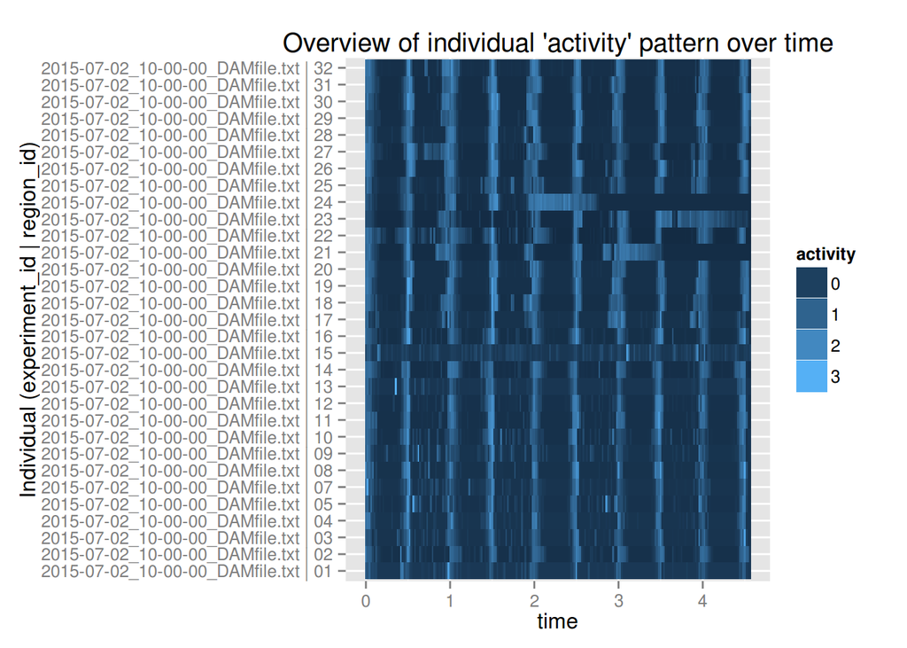

```r
overviewPlot(activity, dam_data, normalise_var_per_id = TRUE)
```

With this representation, you can spot that animals in `region_id` 21 and 24 seemed to have **died before the end ot the experiment**.

## Data curation

The aim of the curation is to:

- remove animals that were dead all along or simply absent.
- remove data *after* death of one animal (but keep the data before).

In order to curate data, we first need to **define movement**. In other words, we want to add a column called `moving` which is `TRUE` if the animal is moving at this time, and `FALSE` otherwise. It turns out that is is excatly what the function `sleepDAMAnnotation`. To apply it to each animal we use a bit of `data.table` wizardry:

```r
dam_data <- dam_data[,sleepDAMAnnotation(.SD),by=key(dam_data)]
print(dam_data)
```

```
##                  start_date  stop_date region_id condition
##      1: 2015-07-02_10-00-00 2015-07-07         1         a
##      2: 2015-07-02_10-00-00 2015-07-07         1         a
##      3: 2015-07-02_10-00-00 2015-07-07         1         a
##      4: 2015-07-02_10-00-00 2015-07-07         1         a
##      5: 2015-07-02_10-00-00 2015-07-07         1         a
##     ---
## 211196: 2015-07-02_10-00-00 2015-07-07        32         b
## 211197: 2015-07-02_10-00-00 2015-07-07        32         b
## 211198: 2015-07-02_10-00-00 2015-07-07        32         b
## 211199: 2015-07-02_10-00-00 2015-07-07        32         b
## 211200: 2015-07-02_10-00-00 2015-07-07        32         b
##                           experiment_id      t activity moving asleep
##      1: 2015-07-02_10-00-00_DAMfile.txt      0        0  FALSE  FALSE
##      2: 2015-07-02_10-00-00_DAMfile.txt     60        2   TRUE  FALSE
##      3: 2015-07-02_10-00-00_DAMfile.txt    120        0  FALSE  FALSE
##      4: 2015-07-02_10-00-00_DAMfile.txt    180        1   TRUE  FALSE
##      5: 2015-07-02_10-00-00_DAMfile.txt    240        1   TRUE  FALSE
##     ---
## 211196: 2015-07-02_10-00-00_DAMfile.txt 395700        0  FALSE   TRUE
## 211197: 2015-07-02_10-00-00_DAMfile.txt 395760        0  FALSE   TRUE
## 211198: 2015-07-02_10-00-00_DAMfile.txt 395820        0  FALSE   TRUE
## 211199: 2015-07-02_10-00-00_DAMfile.txt 395880        0  FALSE   TRUE
## 211200: 2015-07-02_10-00-00_DAMfile.txt 395940        0  FALSE   TRUE
```

Note the new columns: `moving` and `alseep`. Just to check `moving` is relevant, we can repeat the overview plot for `moving`.

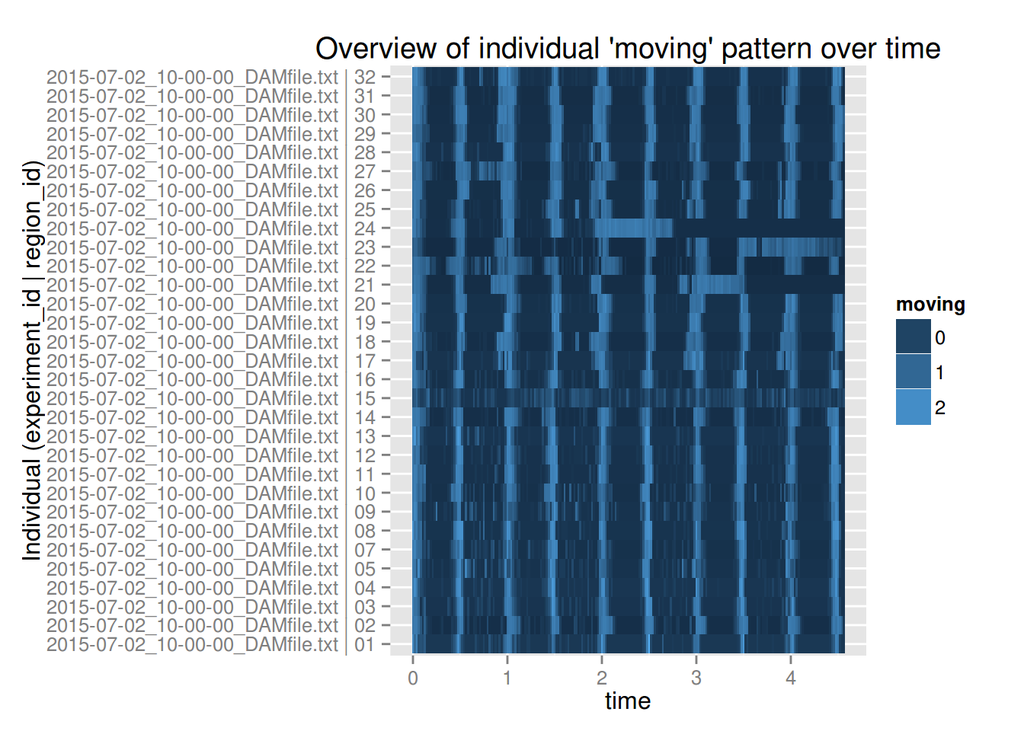

```r
overviewPlot(moving, dam_data, normalise_var_per_id = TRUE)
```

**The important part happens here**, as we apply the function `curateDeadAnimals` to all individuals:

```r
dam_data_curated <- dam_data[,
                             curateDeadAnimals(.SD,hours(12)),
                             by=key(dam_data)]
```

Here, the `hours(12)` means we consider an animal to be dead if and only if it immobile (*i.e.* has not crossed a beam) for at least 12h. Obviously you can change this duration to another another one, such as 10h.

If we replot the graphical overview with the curated data:

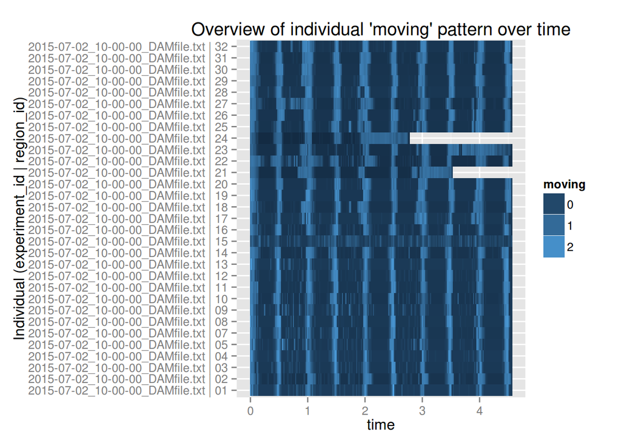

```r
overviewPlot(moving,
             dam_data_curated,
             normalise_var_per_id = TRUE)
```

As you can see, animals 21 and 24 are still present, but instead of being scored as immobile, data is remove after there probable death.

One last thing we can do is compute the **lifespan of each animal**, using `data.table` magic:

```r
life_span <- dam_data_curated[,
                              # `/days(1)` means we express lifespan in days as opposed to seconds
                             .(life_span = (t[.N] - t[1])/days(1)),
                             by=key(dam_data_curated)]
life_span
```

```
##              start_date  stop_date region_id condition
##  1: 2015-07-02_10-00-00 2015-07-07         1         a
##  2: 2015-07-02_10-00-00 2015-07-07         2         a
##  3: 2015-07-02_10-00-00 2015-07-07         3         a
##  4: 2015-07-02_10-00-00 2015-07-07         4         a
##  5: 2015-07-02_10-00-00 2015-07-07         5         a
##  6: 2015-07-02_10-00-00 2015-07-07         7         a
##  7: 2015-07-02_10-00-00 2015-07-07         8         a
##  8: 2015-07-02_10-00-00 2015-07-07         9         a
##  9: 2015-07-02_10-00-00 2015-07-07        10         a
## 10: 2015-07-02_10-00-00 2015-07-07        11         a
## 11: 2015-07-02_10-00-00 2015-07-07        12         a
## 12: 2015-07-02_10-00-00 2015-07-07        13         a
## 13: 2015-07-02_10-00-00 2015-07-07        14         a
## 14: 2015-07-02_10-00-00 2015-07-07        15         a
```

[output cut: 51 more lines]